# Education Data Analysis Sample-Doris Yan

**Data Source**: [National Center for Education Statistics (NCES)](https://nces.ed.gov/ccd/files.asp)

**Objective**: To explore US public school finance trend and equity in terms of distribution of resources across school districts in every state

**Figures**

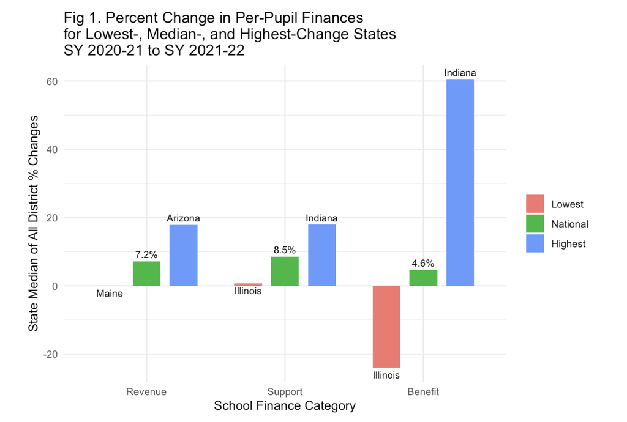

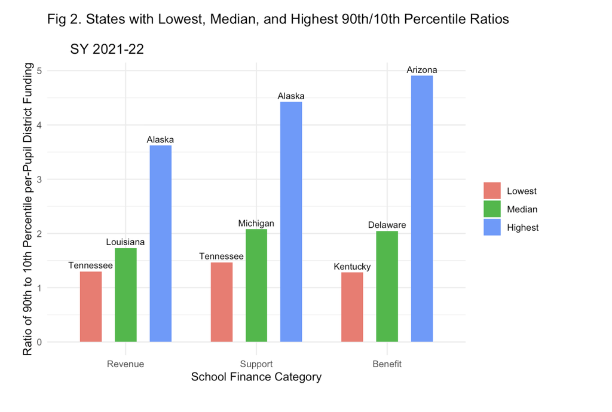

**Findings**

- Figure 1 shows disparities in states’ per-pupil education finances from School Year 2020–21 to 2021–22. The U.S. as a whole experienced increases in revenue and spending (i.e., support and benefit expenditure), but the percent change varied by state. For instance, Indiana had the largest increase in benefit spending at over 60%, while Illinois experienced a decrease of more than 20%. These differences reflect unequal state-level responses in the wake of the pandemic and point to a pattern of school finance inequity across the country.
- Figure 2 highlights the ratio of per-pupil funding between the 90th and 10th percentile districts within each state. Arizona, for example, had a benefit ratio of nearly 5 to 1, indicating a wide spending gap between its highest- and lowest-funded districts. In contrast, Tennessee and Kentucky had much lower ratios, suggesting more equitable distribution. These figures show that in some states, a student’s access to educational resources is tied closely to district wealth. Together, the two graphs reveal inequities in public school funding between states and within them.